# Profile clusters, everyone pooled

Which proteins relate to the phenotype in the same way? Two groupings, with no group label:

- Profiles: each protein is described by its limma t against every trait in every window (the change scores of `01_Trait_Associations`), and proteins with similar profiles are clustered.
- Per trait: for each trait’s training change and T1 level, the proteins at p < 0.05 are grouped by how they co-vary across people, with each group’s direction and main module.

Each group is described by its most over-represented gene set (clusterProfiler’s `enricher()`), with every protein tested in the window as the universe. The groups come from the same t values they summarise, so these descriptions are not tests of the grouping; the mean silhouette reports how separate the groups are.

## Packages

dynamicTreeCut cuts the trees and clusterProfiler runs the enrichment; both are called with `::`.

```r
library(here)
library(dplyr)
library(tidyr)
library(purrr)
library(tibble)
library(ggplot2)
source(here("00_Setup", "Shared_functions", "workbooks.R"))
source(here("00_Setup", "Shared_functions", "person_traits.R"))
inputs <- c(
  corrected = "01_Processing/03_Blood_Correction/c_data/blood_correction.rds",
  associations = "03_Continuous/01_Trait_Associations/c_data/trait_associations.rds",
  gene_sets = "01_Processing/04_Gene_Sets/c_data/gene_sets.rds",
  modules = "01_Processing/06_Module_Building/c_data/module_building.rds"
)
paths <- vapply(inputs, here, character(1))
stopifnot(file.exists(paths))
```

## Input

The blood-corrected matrix, the protein change scores, the gene sets and each protein’s module.

```r
corrected <- readRDS(paths[["corrected"]])
meta <- as_tibble(corrected$targets)
gs <- readRDS(paths[["gene_sets"]])
modules <- readRDS(paths[["modules"]])
gene_of <- with(filter(gs$protein_map, selected), set_names(gene, uniprot_id))
protein_label <- set_names(sub(";.*", "", corrected$genes$Genes), rownames(corrected))
set_label <- with(gs$set_catalog, set_names(pathway, set_id))
module_of <- with(modules$membership, set_names(module, uniprot_id))
observed_t <- readRDS(paths[["associations"]])$change_score |>
  filter(feature_type == "proteins") |>
  select(window, trait, feature, t, p)
term2gene <- tibble(set_id = rep(names(gs$sets), lengths(gs$sets)), gene = unlist(gs$sets))
count(observed_t, window, name = "protein_trait_pairs")
```

```
# A tibble: 6 × 2
  window          protein_trait_pairs
  <chr>                         <int>
1 acute                         16472
2 baseline                      16472
3 baseline_level                12354
4 post_bout_level               12354
5 post_level                    12354
6 training                      16472
```

## Three helpers

`tree_groups()` takes a protein-by-column matrix and a minimum group size, clusters proteins by average linkage on 1 − Pearson r, and cuts the tree with `dynamicTreeCut::cutreeDynamic()`, which finds branches by shape instead of at one height. Proteins it leaves unassigned (group 0) are dropped. It returns each protein’s group and the mean silhouette (how much closer proteins sit to their own group than to the next, −1 to 1).

```r
tree_groups <- function(m, min_size) {
  d <- as.dist(1 - cor(t(m)))
  groups <- dynamicTreeCut::cutreeDynamic(hclust(d, "average"),
    distM = as.matrix(d), minClusterSize = min_size, deepSplit = 2, verbose = 0
  )
  kept <- groups != 0
  silhouette_mean <- if (n_distinct(groups[kept]) < 2) {
    NA_real_
  } else {
    mean(cluster::silhouette(groups[kept], as.dist(as.matrix(d)[kept, kept]))[, "sil_width"])
  }
  list(groups = set_names(groups, rownames(m))[kept], silhouette = silhouette_mean)
}
```

`describe()` takes a group’s proteins and the universe they came from, and returns the most over-represented gene set with its p and FDR (across all sets tested for that group).

```r
describe <- function(members, universe) {
  res <- clusterProfiler::enricher(na.omit(unname(gene_of[members])),
    universe = na.omit(unname(gene_of[universe])), TERM2GENE = term2gene, minGSSize = 15,
    maxGSSize = 500, pvalueCutoff = 1, qvalueCutoff = 1
  )
  if (is.null(res) || nrow(res@result) == 0) {
    return(tibble(top_set = NA_character_, top_set_p = NA_real_, top_set_fdr = NA_real_))
  }
  top <- slice_min(as_tibble(res@result), pvalue, n = 1, with_ties = FALSE)
  tibble(top_set = unname(set_label[top$ID]), top_set_p = top$pvalue, top_set_fdr = top$p.adjust)
}
```

`summarise_groups()` takes each protein’s group and t, and returns one row per group: size, mean t, share moving up, main module, the 15 proteins with the largest |t|, and `describe()`’s top set.

```r
summarise_groups <- function(groups, t, universe) {
  tibble(feature = names(groups), group = groups, t = t[names(groups)]) |>
    summarise(
      n_proteins = n(), mean_t = mean(t), share_positive = mean(t > 0), members = list(feature),
      main_module = names(which.max(table(module_of[feature]))),
      proteins = paste(head(protein_label[feature][order(-abs(t))], 15), collapse = ", "),
      .by = group
    ) |>
    mutate(enrichment = map(members, \(m) describe(m, universe))) |>
    unnest(enrichment) |>
    select(-members) |>
    arrange(group)
}
```

## Association profiles

Each protein’s row holds its t against every window-and-trait screen.

```r
profiles <- observed_t |>
  transmute(feature, screen = paste(window, trait), t) |>
  pivot_wider(names_from = screen, values_from = t) |>
  column_to_rownames("feature") |>
  as.matrix()
stopifnot(!anyNA(profiles))
profile_cut <- tree_groups(profiles, min_size = 20)
profile_summary <- summarise_groups(profile_cut$groups, rowMeans(profiles), rownames(profiles))
profile_means <- as_tibble(profiles[names(profile_cut$groups), ], rownames = "feature") |>
  mutate(group = profile_cut$groups) |>
  pivot_longer(-c(feature, group), names_to = "screen", values_to = "t") |>
  summarise(mean_t = mean(t), .by = c(group, screen))
c(
  proteins = nrow(profiles), screens = ncol(profiles), groups = n_distinct(profile_cut$groups),
  silhouette = round(profile_cut$silhouette, 3)
)
```

```
  proteins    screens     groups silhouette
  2059.000     42.000     50.000      0.027
```

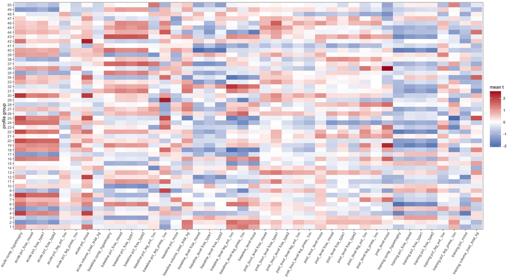

Figure 1: Mean limma t per profile group and screen.

```r
ggplot(profile_means, aes(screen, factor(group), fill = mean_t)) +
  geom_tile() +
  scale_fill_gradient2(low = "#2166AC", high = "#B2182B", name = "mean t") +
  labs(x = NULL, y = "profile group") +
  theme_bw(base_size = 7) +
  theme(axis.text.x = element_text(angle = 60, hjust = 1))
```

## Co-variation groups per trait

For the training and T1-level windows, each trait’s p < 0.05 proteins are clustered on their values across people (training change, or T1 level), at least 8 proteins to a group. The universe for the enrichment is every protein tested in that window.

```r
matrix_of <- list(
  training = person_values(corrected$E, meta, "T2", from = "T1"),
  baseline_level = person_values(corrected$E, meta, "T1")
)
trait_groups <- observed_t |>
  filter(window %in% names(matrix_of), p < 0.05) |>
  nest(.by = c(window, trait)) |>
  mutate(result = map2(window, data, \(w, hits) {
    cut <- tree_groups(matrix_of[[w]][hits$feature, , drop = FALSE], min_size = 8)
    universe <- filter(observed_t, window == w)$feature
    summarise_groups(cut$groups, set_names(hits$t, hits$feature), universe) |>
      mutate(silhouette = cut$silhouette, n_hits = nrow(hits))
  })) |>
  select(-data) |>
  unnest(result)
count(trait_groups, window, trait, name = "groups")
```

```
# A tibble: 14 × 3
   window         trait                groups
   <chr>          <chr>                 <int>
 1 baseline_level fcsa_mixed                7
 2 baseline_level fcsa_type1                5
 3 baseline_level fcsa_type2                8
 4 baseline_level leg_ext_1rm              10
 5 baseline_level leg_press_1rm            10
 6 baseline_level mcsa                      5
 7 training       comp_hypertrophy          7
 8 training       pct_fcsa_mixed            3
 9 training       pct_fcsa_type1            3
10 training       pct_fcsa_type2            3
11 training       pct_leg_ext_1rm           4
12 training       pct_leg_press_1rm         3
13 training       pct_mcsa                  4
14 training       volume_load_total_kg      5
```

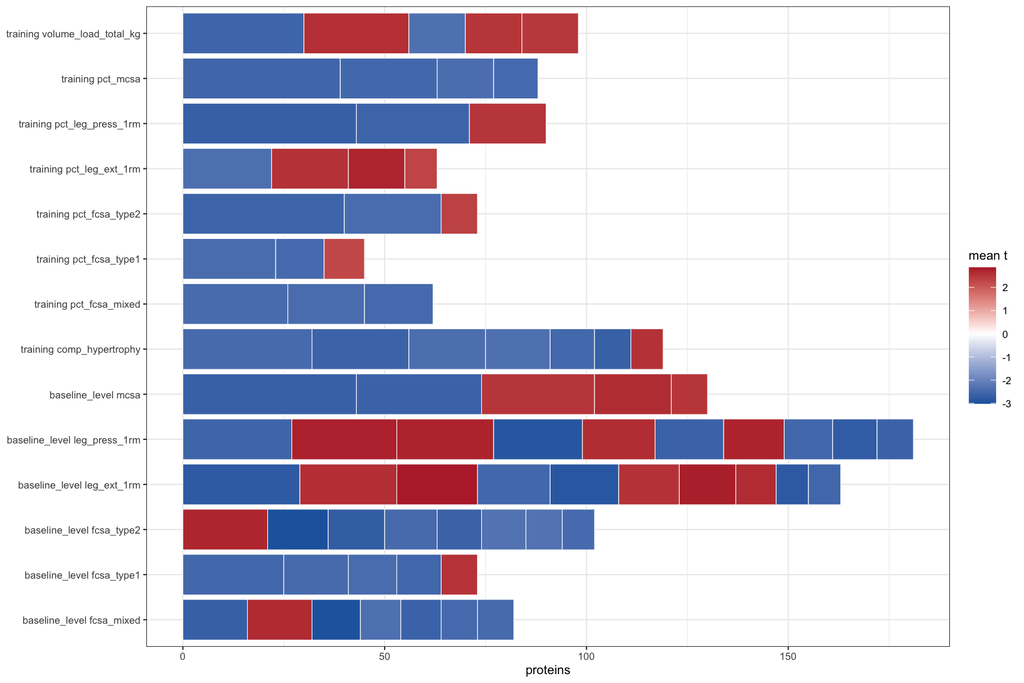

Figure 2: Co-variation groups among each trait’s p < 0.05 proteins; fill: the group’s mean t.

```r
ggplot(trait_groups, aes(n_proteins, paste(window, trait), fill = mean_t)) +
  geom_col(position = position_stack(), colour = "white", linewidth = 0.2) +
  scale_fill_gradient2(low = "#2166AC", high = "#B2182B", name = "mean t") +
  labs(x = "proteins", y = NULL) +
  theme_bw(base_size = 8)
```

## Validation

```r
stopifnot(
  all(names(profile_cut$groups) %in% rownames(profiles)),
  sum(profile_summary$n_proteins) == length(profile_cut$groups),
  all(trait_groups$n_proteins >= 8), all(trait_groups$n_proteins <= trait_groups$n_hits)
)
```

## Summary

50 profile groups hold 2059 of 2059 proteins (mean silhouette 0.03); the largest holds 113. 77 co-variation groups over 14 trait and window pairs.

## Save

`profile_clusters.rds` holds the profile groups and the per-trait groups for the figures.

```r
out <- here("03_Continuous", "03_Profile_Clusters", "c_data")
dir.create(out, showWarnings = FALSE)
profile_members <- tibble(
  feature = names(profile_cut$groups), label = unname(protein_label[names(profile_cut$groups)]),
  group = profile_cut$groups
)
saveRDS(
  list(
    profile_groups = profile_summary, profile_members = profile_members,
    profile_means = profile_means, trait_groups = trait_groups
  ),
  file.path(out, "profile_clusters.rds")
)
write_workbook(
  list(
    profile_groups = profile_summary, profile_members = profile_members,
    profile_means = profile_means, trait_groups = trait_groups
  ),
  c(
    sprintf(
      "Profile groups: size, mean t, main module, top over-represented set; mean silhouette %.3f.",
      profile_cut$silhouette
    ),
    "Each protein's profile group.",
    "Mean limma t per profile group and screen.",
    "Per trait and window: co-variation groups among p < 0.05 proteins, with silhouette and ORA."
  ),
  file.path(out, "profile_clusters.xlsx"), inputs, paths
)
```